# Project 5

Creating data from digital sources

yungyu lee

## Part A

- My choice of datat context is exploration of weather data for specific city in New zealand
- I have chosen this data context to have insight into climate patterns and help predict future weather conditions.

```r
library(tidyverse)
library(rvest)

#My data context is weather data for specific city in New zealand

#Information from the webpages that might be useful to scrape:
# windspeed, forecast for the next few days, humidity
# Weather condition

#Wesites for web scrapping
#Metservice(https://www.metservice.com/national)
#The policy states that the information from the site observational data is a open acess data
#No robots.txt disallows for web scrapping
#Weatherwatch("https://www.weatherwatch.co.nz/")
#No specific restriction about web scrapping and data colleciton from the stie
#No robots.txt disallows for web scrapping

url <- "https://www.weatherwatch.co.nz/forecasts/Auckland"

page <- read_html(url)

#Weather info
weather_info<- page %>%
  html_elements(".jsx-3024714417.details.grid-item.grid-width-2") %>%
  html_elements("span.jsx-3024714417.figure") %>%
  html_text2()

#humidity
humidity<- weather_info[4]

#wind_speed
wind_speed<- weather_info[2]

#wearther_pressure
Pressure<- weather_info[5]

#Since all the weather information are int group as classfied in the same div class
#with same span so i had to specifty the number in the vector to assign the each value

#city temperature
city_temp <- page %>%
  html_element(".temp") %>%
  html_text2()

output<- paste("Humidity:", humidity, "\n",
               "Wind speed:", wind_speed, "\n",
               "Wind pressure:", Pressure, "\n",
               "City temperature", city_temp, "\n"
               )

cat(output)
```

```
## Humidity: 74 %
##  Wind speed: NNW 0 km/h
##  Wind pressure: 1006.1 hPa
##  City temperature 17 °
```

## Part B

```r
library(tidyverse)
library(rvest)

#minister selected: "Hon Shane Jones"
#Releases (1) "Report provides insights into marine recovery"
#Report consist usage of many quotation mark
#frequent word used in "cyclones", "marine ecosystems"and "fishery managers".
#Report length is pretty consistent with few lines in each paragraph and have consistent format across the report
#Not much use of specific symbols in the report

#Releases (2) "Low gas production threatens energy security"
#Key terms such as "gas production" and "investment confidence" are repeated in the report
#Sentiment within the report are critical and urgent due to words used such as "terrible threat", "threat to economies"
#The length of each paragraph consistent throughout the report it has moderate length of lines
#minimal use of symbols and punctuation used in the report


url <- "https://www.beehive.govt.nz/minister/hon-shane-jones"

pages <- read_html(url) %>%
  html_elements(".release__wrapper") %>%
  html_elements("h2") %>%
  html_elements("a") %>%
  html_attr("href") %>%
  paste0("https://www.beehive.govt.nz", .)

page_url <- pages[1]

page <- read_html(page_url)

release_title <- page %>%
  html_elements("h1") %>%
  html_text2()

release_content <- page %>%
  html_elements(".prose") %>%
  html_text2() %>%
  str_replace_all("\n", " ")


tib_data <- tibble(release_title, release_content)

get_release <- function(page_url){
  Sys.sleep(2)
  print(page_url)
  page <- read_html(page_url)

  release_title <- page %>%
    html_elements("h1") %>%
    html_text2()

  release_content <- page %>%
    html_elements(".prose") %>%
    html_text2()


  tibble_data <- tibble(release_title, release_content)

}

release_data <- map_df(pages, get_release)

#average word length in the release_title/ word length in title
mean_word_length_title <- mean(str_count(release_data$release_title, "\\w+")) %>%
  round(1)

#average word length in the release content
mean_word_length_content <- mean(str_count(release_data$release_content, "\\w+")) %>%
  round(1)

#most common word in release content
top_words_use_content <- release_data$release_content %>%
  str_split("\\s+") %>%
  unlist() %>%
  table() %>% #gives frequency as output
  sort(decreasing= TRUE) %>%
  names() %>% #corresponding value of each count
  head(10) # top 10 character vector

#Count of unique words in release content
unique_word_release_content <- release_data$release_content %>%
  str_split("\\w+") %>%
  unlist() %>%
  unique() %>%
  length()
```

- The mean count of word length for minister’s releases in title have length of 6.7
- The mean count of word length for minister’s releases content have length of 378
- Out of all the minister’s release content’s the top 10 most used word in the content are “the, and, to, of, in, a, for, is, on, Jones”
- Based on the minister’s release content, count of unique word in the release content is 49

## Part C

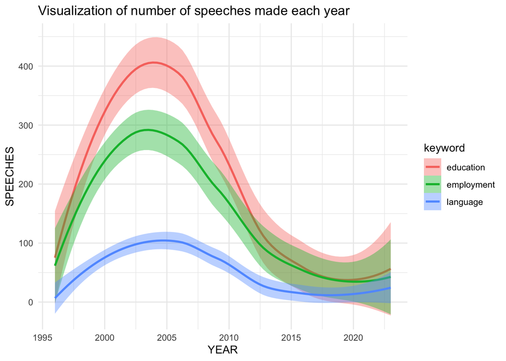

```r
library(tidyverse)
library(rvest)
library(dplyr)

keywords <- c("education", "employment", "language")

search1 <- read_html(paste0("https://datalandscapes.online/scrapeable/speeches.php?search=", keywords[1])) %>%
  html_elements(".speech_summary") %>%
  html_text2() %>%
  tibble(keyword = keywords[1],
         results = .) %>%
  separate(results, into = c("year", "num_speeches"), sep = "--") %>%
  mutate(num_speeches = parse_number(num_speeches),
         year = parse_number(year))


search2 <- read_html(paste0("https://datalandscapes.online/scrapeable/speeches.php?search=", keywords[2])) %>%
  html_elements(".speech_summary") %>%
  html_text2() %>%
  tibble(keyword = keywords[2],
         results = .) %>%
  separate(results, into = c("year", "num_speeches"), sep = "--") %>%
  mutate(num_speeches = parse_number(num_speeches),
         year = parse_number(year))

search3 <- read_html(paste0("https://datalandscapes.online/scrapeable/speeches.php?search=", keywords[3])) %>%
  html_elements(".speech_summary") %>%
  html_text2() %>%
  tibble(keyword = keywords[3],
         results = .) %>%
  separate(results, into = c("year", "num_speeches"), sep = "--") %>%
  mutate(num_speeches = parse_number(num_speeches),
         year = parse_number(year))

combined_search <- bind_rows(search1, search2, search3)

speeches_governments <- read_csv("https://docs.google.com/spreadsheets/d/e/2PACX-1vRHTFJcFmsIkjaFUCEwFWASaBOAR4X2Upx66C5Bhgc_WNc2JxxdRbbvyoewmvt_EjNdCNZZzzkENwLg/pub?gid=0&single=true&output=csv")

speech_data <- left_join(combined_search, speeches_governments, by= "year")

speech_plot <- speech_data %>%
  ggplot(aes(x= year,
             y= num_speeches,
             fill= keyword)) +
  geom_smooth(method= "loess", aes(colour= keyword))+
  labs(title= "Visualization of number of speeches made each year",
       x= "YEAR",
       y= "SPEECHES") +
  theme_minimal()

speech_plot
```

- Plot for visualization shows the count of speeches given yearly, colored with different color of keywords

## Learning reflection

- Upon doing this assignment, one important idea I learned from the course was identifying and extracting appropriate elements from the web source. Understanding the key elements required for the purpose of data context to gather needed data seemed like an like an important factor in web scraping. Alongside collecting appropriate elements, carefully choosing a source for web scraping was another idea from the module. Paying attention to the policies and guides provided by the web source is important. When doing web scrapping, I was interested in learning more about web scrapping tools from other programs, such as Python and Node.js, to extract data from HTML documents on websites.

## Self review

- My ability to program with R has improved significantly over the course. Two skills that I have developed are data manipulation and data visualization. Through understanding different packages such as {tidyverse} and {rvest}, I’m able to widen my expression to include much more variables. Techniques such as extracting information from the strings, simple mathematical operations, and learning different types of joins (inner, left, and right) to combine datasets. I’m confident in data visualization from using {tidyverse} and {magick} packages. Formatting different visualizations through the use of many geom functions and image processing through {magick} functions are key skills I learned from the projects.